```r
knitr::opts_chunk$set(tidy=TRUE, highlight=TRUE, dev="png",
               cache=TRUE, highlight=TRUE, autodep=TRUE, warning=FALSE, error=FALSE,
               message=FALSE, prompt=TRUE, comment='', fig.cap='')
```

```r
> library(ggplot2)
> library(dplyr)
> library(tidyr)
> library(biomaRt)
> library(pheatmap)
```

# Overview

This is looking at a first sequencing run of single cells. There are three samples, `H1`, `H2` and `H3`. There is some prior knowledge that the `H1` sample might have some quality problems.

## Barcode distributions

For a single-cell experiment, we expect to see a set of barcodes that come from real cells and then a drop. Below we show the barcode distribution for a published experiment on K562 cells and then each of these samples. We look at only the top 100,000 barcodes for each sample.

If you click on the tabs you can see each of the charts. We can see that the samples are missing the characteristic dip in the barcode distribution. Normally we would use this dip to determine a cutoff to filter out real cells.

This may be due to there not being enough depth of sequencing or it may be due to the samples having something wrong with them. It would be helpful to ask the sequencing core what they think about this.

```r
> samples = c("H1", "H2", "H3")
> barcode_files = file.path("umis", samples, "cb-histogram.txt")
```

### K562

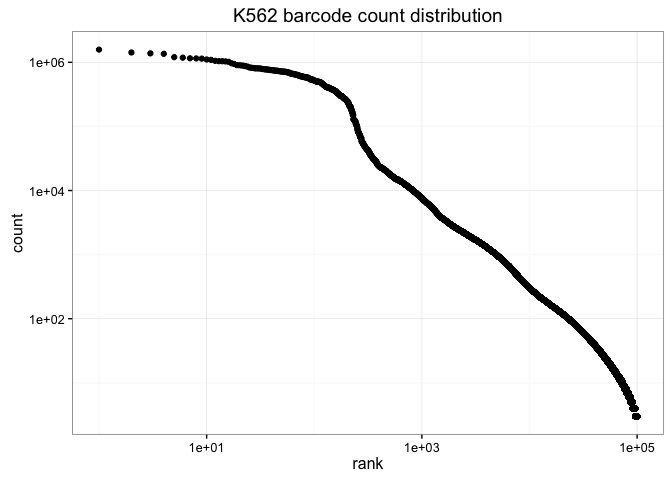

```r
> K562_bc = read.table("metadata/k562-histogram.txt", header = FALSE, sep = "\t",
+     nrows = 1e+05)
> colnames(K562_bc) = c("barcode", "count")
> K562_bc$rank = as.numeric(rownames(K562_bc))
> ggplot(K562_bc, aes(rank, count)) + scale_x_log10() + scale_y_log10() + geom_point() +
+     theme_bw() + ggtitle("K562 barcode count distribution")
```

### K562 (60 million)

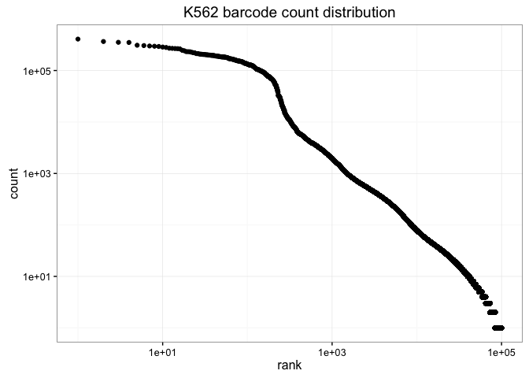

```r
> K562_small = read.table("metadata/k562-histogram-60million.txt", header = FALSE,
+     sep = "\t", nrows = 1e+05)
> colnames(K562_small) = c("barcode", "count")
> K562_small$rank = as.numeric(rownames(K562_small))
> ggplot(K562_small, aes(rank, count)) + scale_x_log10() + scale_y_log10() + geom_point() +
+     theme_bw() + ggtitle("K562 barcode count distribution")
```

### H1

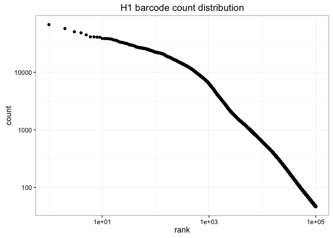

```r
> h1_bc = read.table(barcode_files[1], header = FALSE, sep = "\t", nrows = 1e+05)
> colnames(h1_bc) = c("barcode", "count")
> h1_bc$rank = as.numeric(rownames(h1_bc))
> ggplot(h1_bc, aes(rank, count)) + scale_x_log10() + scale_y_log10() + geom_point() +
+     theme_bw() + ggtitle("H1 barcode count distribution")
```

### H2

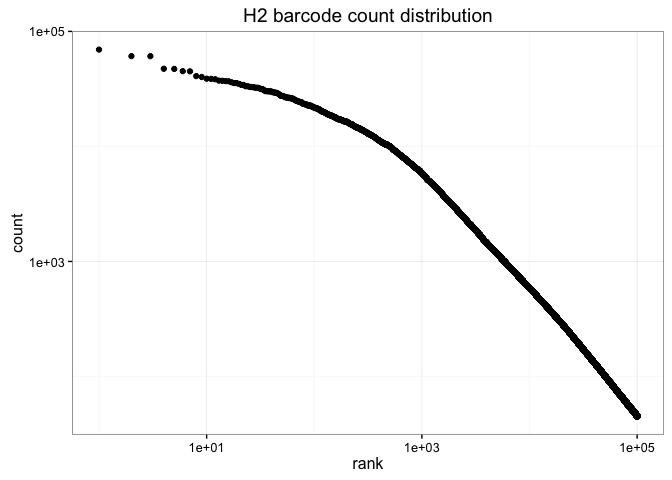

```r
> h2_bc = read.table(barcode_files[2], header = FALSE, sep = "\t", nrows = 1e+05)
> colnames(h2_bc) = c("barcode", "count")
> h2_bc$rank = as.numeric(rownames(h2_bc))
> ggplot(h2_bc, aes(rank, count)) + scale_x_log10() + scale_y_log10() + geom_point() +
+     theme_bw() + ggtitle("H2 barcode count distribution")
```

### H3

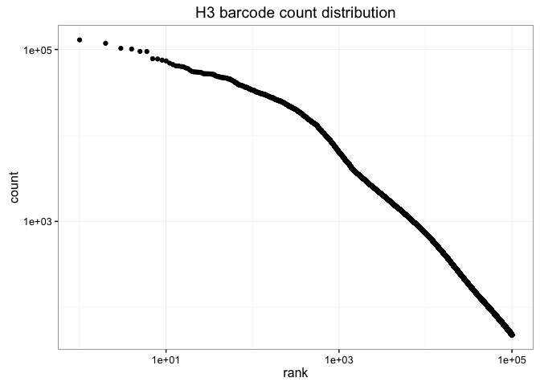

```r
> h3_bc = read.table(barcode_files[3], header = FALSE, sep = "\t", nrows = 1e+05)
> colnames(h3_bc) = c("barcode", "count")
> h3_bc$rank = as.numeric(rownames(h3_bc))
> ggplot(h3_bc, aes(rank, count)) + scale_x_log10() + scale_y_log10() + geom_point() +
+     theme_bw() + ggtitle("H3 barcode count distribution")
```

# Count based quality control

Here we compare the counts for the K562 data as well as for each of the proximal tubule samples, using several different metrics. We counted at the level of the transcript, so before continuing we will collapse the transcript level counts to gene level counts by summing the counts for each transcript for each gene.

```r
> mart = useMart(biomart = "ENSEMBL_MART_ENSEMBL", dataset = "mmusculus_gene_ensembl",
+     host = "jul2015.archive.ensembl.org")
> conversions = getBM(attributes = c("ensembl_gene_id", "ensembl_transcript_id",
+     "mgi_symbol"), mart = mart)
> load_counts = function(count_file) {
+     counts = read.table(count_file, header = TRUE, sep = ",")
+     counts = counts %>% dplyr::left_join(conversions, c(gene = "ensembl_transcript_id")) %>%
+         dplyr::filter(mgi_symbol != "") %>% dplyr::select(-gene, -ensembl_gene_id) %>%
+         tidyr::gather(cell, count, -mgi_symbol) %>% dplyr::group_by(cell, mgi_symbol) %>%
+         dplyr::summarise(counts = sum(count)) %>% tidyr::spread(cell, counts,
+         fill = 0)
+     counts = as.data.frame(counts)
+     rownames(counts) = counts$mgi_symbol
+     counts$mgi_symbol = NULL
+     return(counts)
+ }
```

```r
> load_k562 = function(count_file) {
+     k562 = read.table(count_file, header = TRUE, sep = ",") %>% tidyr::separate(gene,
+         into = c("transcript", "symbol"), sep = "\\|") %>% dplyr::select(-transcript) %>%
+         tidyr::gather(cell, count, -symbol) %>% dplyr::group_by(cell, symbol) %>%
+         dplyr::summarise(counts = sum(count)) %>% tidyr::spread(cell, counts,
+         fill = 0)
+     k562 = as.data.frame(k562)
+     rownames(k562) = k562$symbol
+     k562$symbol = NULL
+     return(k562)
+ }
```

```r
> k562 = load_k562("metadata/k562.counts")
> k562_pseudo = load_k562("metadata/k562-pseudo-60million.counts")
> k562_quasi = load_k562("metadata/k562-quasi-60million.counts")
> count_files = file.path("umis", samples, paste(samples, ".counts", sep = ""))
> h1 = load_counts(count_files[1])
> h2 = load_counts(count_files[2])
> h3 = load_counts(count_files[3])
```

We’ll look at just the top 150 cells with the most counts in each sample, so we can compare more easily to the K562 cells.

```r
> top_n_cell = function(counts, n = 150) {
+     counts = counts[, head(order(colSums(counts), decreasing = TRUE), n)]
+     return(counts)
+ }
> k562 = top_n_cell(k562)
> k562_pseudo = top_n_cell(k562_pseudo)
> k562_quasi = top_n_cell(k562_quasi)
> h1 = top_n_cell(h1)
> h2 = top_n_cell(h2)
> h3 = top_n_cell(h3)
```

## Genes Detected

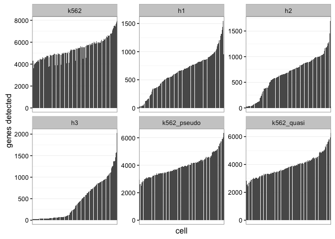

```r
> k562_detected = data.frame(cell = colnames(k562), total = colSums(k562), detected = colSums(k562 >
+     0), sample = "k562")
> k562_pseudo_detected = data.frame(cell = colnames(k562_pseudo), total = colSums(k562_pseudo),
+     detected = colSums(k562_pseudo > 0), sample = "k562_pseudo")
> k562_quasi_detected = data.frame(cell = colnames(k562_quasi), total = colSums(k562_quasi),
+     detected = colSums(k562_quasi > 0), sample = "k562_quasi")
> h1_detected = data.frame(cell = colnames(h1), total = colSums(h1), detected = colSums(h1 >
+     0), sample = "h1")
> h2_detected = data.frame(cell = colnames(h2), total = colSums(h2), detected = colSums(h2 >
+     0), sample = "h2")
> h3_detected = data.frame(cell = colnames(h3), total = colSums(h3), detected = colSums(h3 >
+     0), sample = "h3")
> detected = rbind(k562_detected, h1_detected, h2_detected, h3_detected, k562_pseudo_detected,
+     k562_quasi_detected)
> detected = transform(detected, cell = reorder(cell, -detected))
>
> ggplot(detected, aes(reorder(cell, detected), detected)) + geom_bar(stat = "identity",
+     position = "dodge") + facet_wrap(~sample, scale = "free") + theme_bw() +
+     scale_x_discrete(breaks = NULL) + xlab("cell") + ylab("genes detected")
```

We can also try to measure the complexity of the library, looking at how many different genes are detected plotted against the total number of counts. Here we can see that these libraries have a fairly poor distribution of counts.

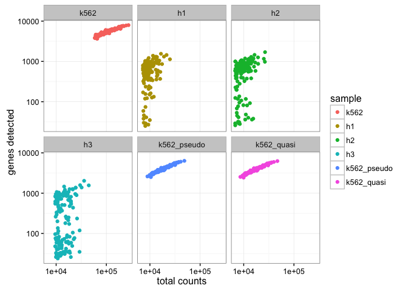

```r
> ggplot(detected, aes(total, detected, color = sample)) + geom_point() + scale_y_log10() +
+     scale_x_log10() + facet_wrap(~sample) + theme_bw() + xlab("total counts") +
+     ylab("genes detected")
```

We couldn’t identify a very good cutoff for number of reads looking at the barcode distribution because we were missing the dip. We can see, however, that even if we applied a pretty stringent cutoff we’d still have many cells with a poor number of genes detected per read. Here we take just the top 100 cells and replot them and it still looks pretty grim:

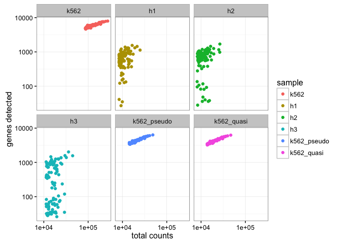

```r
> top_100 = detected %>% group_by(sample) %>% top_n(100, total)
> ggplot(top_100, aes(total, detected, color = sample)) + geom_point() + scale_y_log10() +
+     scale_x_log10() + facet_wrap(~sample) + theme_bw() + xlab("total counts") +
+     ylab("genes detected")
```

## Number of cells genes are expressed

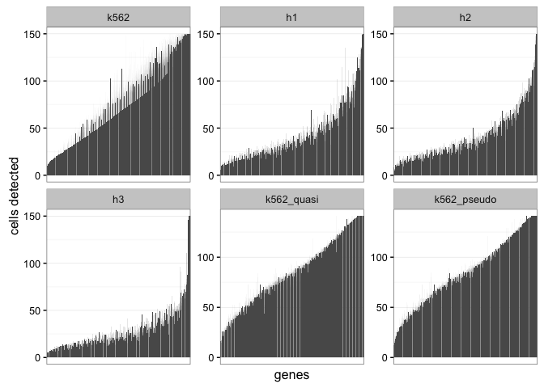

```r
> k562_detected = data.frame(gene = rownames(k562), total = rowSums(k562), detected = rowSums(k562 >
+     0), sample = "k562")
> k562_pseudo_detected = data.frame(gene = rownames(k562_pseudo), total = rowSums(k562_pseudo),
+     detected = rowSums(k562_pseudo > 0), sample = "k562_pseudo")
> k562_quasi_detected = data.frame(gene = rownames(k562_quasi), total = rowSums(k562_quasi),
+     detected = rowSums(k562_quasi > 0), sample = "k562_quasi")
> h1_detected = data.frame(gene = rownames(h1), total = rowSums(h1), detected = rowSums(h1 >
+     0), sample = "h1")
> h2_detected = data.frame(gene = rownames(h2), total = rowSums(h2), detected = rowSums(h2 >
+     0), sample = "h2")
> h3_detected = data.frame(gene = rownames(h3), total = rowSums(h3), detected = rowSums(h3 >
+     0), sample = "h3")
> detected = rbind(k562_detected, h1_detected, h2_detected, h3_detected, k562_quasi_detected,
+     k562_pseudo_detected)
> detected = transform(detected, gene = reorder(gene, -detected))
> detected = subset(detected, total > 100)
> ggplot(detected, aes(reorder(gene, detected), detected)) + geom_bar(stat = "identity",
+     position = "dodge") + facet_wrap(~sample, scale = "free") + theme_bw() +
+     scale_x_discrete(breaks = NULL) + xlab("genes") + ylab("cells detected")
```

## Most variable genes

Here we take a shot at identifying the most variable genes to do PCA with, it is tough with the samples we have because they are very low cou`nts.

### K562

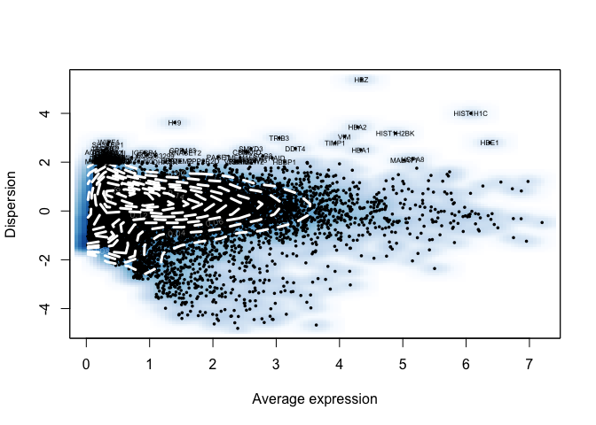

```r
> library(Seurat)
> k562.dat = k562
> colnames(k562.dat) = paste(colnames(k562.dat), "k562", sep = "_")
> k562.seurat = new("seurat", raw.data = log(k562.dat + 1))
> k562.seurat = setup(k562.seurat, project = "k562", min.cells = 3, min.genes = 500,
+     is.expr = 0.01, names.field = 2, names.delim = "_")
> k562.seurat = mean.var.plot(k562.seurat, y.cutoff = 2, do.plot = TRUE, x.low.cutoff = 0.25,
+     x.high.cutoff = 7, fxn.x = expMean, fxn.y = logVarDivMean)
```

### H1

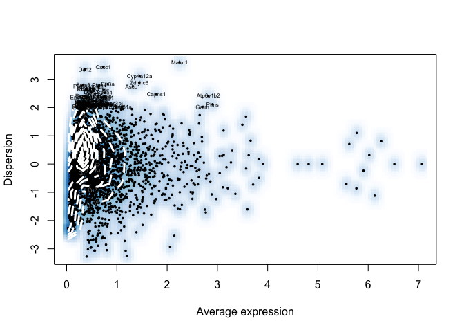

```r
> h1.dat = h1
> colnames(h1.dat) = paste(colnames(h1.dat), "h1", sep = "_")
> h1.seurat = new("seurat", raw.data = log(h1.dat + 1))
> h1.seurat = setup(h1.seurat, project = "h1", min.cells = 3, min.genes = 500,
+     is.expr = 0.01, names.field = 2, names.delim = "_")
> h1.seurat = mean.var.plot(h1.seurat, y.cutoff = 2, do.plot = TRUE, x.low.cutoff = 0.25,
+     x.high.cutoff = 7, fxn.x = expMean, fxn.y = logVarDivMean)
```

### H2

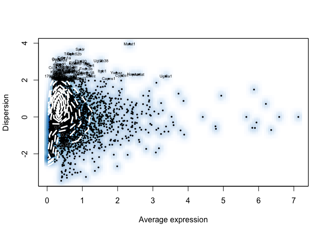

```r
> h2.dat = h2
> colnames(h2.dat) = paste(colnames(h2.dat), "h2", sep = "_")
> h2.seurat = new("seurat", raw.data = log(h2.dat + 1))
> h2.seurat = setup(h2.seurat, project = "h2", min.cells = 3, min.genes = 500,
+     is.expr = 0.01, names.field = 2, names.delim = "_")
> h2.seurat = mean.var.plot(h2.seurat, y.cutoff = 2, do.plot = TRUE, x.low.cutoff = 0.25,
+     x.high.cutoff = 7, fxn.x = expMean, fxn.y = logVarDivMean)
```

### H3

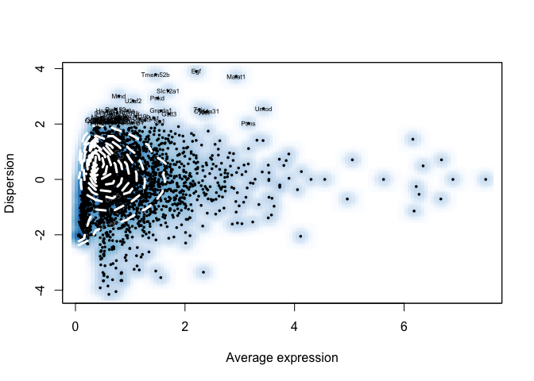

```r
> h3.dat = h3
> colnames(h3.dat) = paste(colnames(h3.dat), "h3", sep = "_")
> h3.seurat = new("seurat", raw.data = log(h3.dat + 1))
> h3.seurat = setup(h3.seurat, project = "h3", min.cells = 3, min.genes = 500,
+     is.expr = 0.01, names.field = 2, names.delim = "_")
> h3.seurat = mean.var.plot(h3.seurat, y.cutoff = 2, do.plot = TRUE, x.low.cutoff = 0.25,
+     x.high.cutoff = 7, fxn.x = expMean, fxn.y = logVarDivMean)
```

## Most variable gene tables

### K562

```r
> k562.seurat@var.genes
```

```
 [1] "AC093375.1" "ACRBP"      "ATP1A1-AS1" "ATRAID"     "BZW2"
 [6] "C14orf80"   "C21orf67"   "CACNA1I"    "CDKN1A"     "CSNK1D"
[11] "DDIT4"      "DEGS2"      "DHRSX"      "DSC2"       "EDEM2"
[16] "EEA1"       "FBXW5"      "FGF13"      "FGGY"       "GAB1"
[21] "GABRG1"     "GDAP1"      "GNG12"      "GPR183"     "GXYLT2"
[26] "H19"        "HBA1"       "HBA2"       "HBBP1"      "HBD"
[31] "HBE1"       "HBZ"        "HFE2"       "HIST1H1C"   "HIST1H2BK"
[36] "HSPA8"      "IGF1"       "IGFBP4"     "LINC00659"  "LIPH"
[41] "LOC283299"  "LPAR2"      "MALAT1"     "MKNK1-AS1"  "MLH3"
[46] "NAPSA"      "NEDD1"      "NR1D2"      "PAGE1"      "PDE6B"
[51] "PIGB"       "PLA2G16"    "PPP2R2D"    "PRKAG2"     "RMRP"
[56] "RNASET2"    "SARNP"      "SCAPER"     "SCG3"       "SESTD1"
[61] "SH3KBP1"    "SLC17A7"    "SMYD3"      "ST7L"       "STXBP6"
[66] "SYF2"       "THBD"       "TIMP1"      "TMEM140"    "TMEM158"
[71] "TMEM198"    "TREML2"     "TRIB3"      "VAMP5"      "VIM"
[76] "VPS51"      "WIPF1"      "ZBED8"      "ZBTB14"     "ZBTB33"
[81] "ZDHHC23"    "ZNF586"
```

### H1

```r
> h1.seurat@var.genes
```

```
 [1] "Adipor2"  "Amotl2"   "Arsb"     "Ascc1"    "Atf7"     "Atg13"
 [7] "Atp6v1b2" "Atxn10"   "Bag2"     "Bmpr1a"   "Bms1"     "Capns1"
[13] "Cdr2"     "Celsr2"   "Cflar"    "Copg1"    "Crtc3"    "Cxxc1"
[19] "Cyp4a12a" "Cyp4a12b" "Derl2"    "Dnajc1"   "Dnajc9"   "Dpm2"
[25] "Efr3a"    "Epm2aip1" "Fam53c"   "Fam60a"   "Fbrsl1"   "Fbxl20"
[31] "Fitm1"    "Fnbp1"    "Frs3"     "Gatm"     "Hbs1l"    "Hnrnpc"
[37] "Inpp5f"   "Irf2bp1"  "Iws1"     "Malat1"   "Mpi"      "Mylk"
[43] "Nras"     "Nt5dc2"   "Patl1"    "Pcna"     "Pex11b"   "Pex16"
[49] "Pias4"    "Plxna2"   "Psmd12"   "Ptms"     "Ptpn1"    "Rbbp5"
[55] "Rbm4b"    "Sav1"     "Sec31a"   "Snx13"    "Sp1"      "Sptb"
[61] "Stk24"    "Strn4"    "Stx12"    "Syne4"    "Taok2"    "Tial1"
[67] "Tmem135"  "Ucp2"     "Unc5c"    "Wbp5"     "Zdhhc6"   "Zmiz1"
[73] "Zwint"
```

### H2

```r
> h2.seurat@var.genes
```

```
 [1] "1700020I14Rik" "Aadat"         "Akr1c18"       "Akt1"
 [5] "Anxa5"         "Apela"         "Arid2"         "Capns1"
 [9] "Ccdc114"       "Cdk12"         "Cdkn1a"        "Chka"
[13] "Chsy1"         "Clec2h"        "Copg1"         "Cpsf2"
[17] "Creb3l1"       "Cse1l"         "Cyp2e1"        "Cyp4a12a"
[21] "Dpep1"         "Egf"           "Eif2ak1"       "Eif4ebp2"
[25] "Elp2"          "Fbxl20"        "Fndc3b"        "Gas1"
[29] "Gbe1"          "Gmppa"         "Gtpbp1"        "H2-Eb1"
[33] "Hpcal1"        "Igf2"          "Irf2bp1"       "Itgb1"
[37] "Kctd13"        "Kdm6b"         "Malat1"        "Mrrf"
[41] "Napsa"         "Nipsnap3b"     "Nsf"           "Nsun4"
[45] "Orai1"         "Paip1"         "Pde6d"         "Pex16"
[49] "Pigyl"         "Pls1"          "Ppp2r2d"       "Psat1"
[53] "Qprt"          "Rabgap1"       "Rqcd1"         "Rybp"
[57] "Sh3rf1"        "Slc12a2"       "Slc25a45"      "Slc35e2"
[61] "Smarca2"       "Snx13"         "Snx15"         "Socs7"
[65] "Sp1"           "Spc25"         "Spidr"         "Sptb"
[69] "Tmem52b"       "Tsix"          "Ttc9c"         "Tulp3"
[73] "Ubxn2b"        "Ugt2b38"       "Ugt3a1"        "Usp6nl"
[77] "Xist"          "Ywhaz"         "Zdhhc6"        "Zwint"
```

### H3

```r
> h3.seurat@var.genes
```

```
 [1] "1810026J23Rik" "9430016H08Rik" "Acp2"          "Ago3"
 [5] "Aldh1a1"       "Ccdc174"       "Cdk9"          "Crbn"
 [9] "Cyp24a1"       "Cyp4a31"       "Derl2"         "Dync2li1"
[13] "Efr3a"         "Egf"           "Fbrsl1"        "Gnpda1"
[17] "Gstm7"         "Gstt3"         "Hs1bp3"        "Igf1r"
[21] "Malat1"        "Mmd"           "Mt1"           "Pin1"
[25] "Pnkd"          "Prodh2"        "Prps1"         "Ptms"
[29] "Rnf152"        "Scamp1"        "Sema5a"        "Sgms2"
[33] "Slc12a1"       "Slc25a36"      "Slc40a1"       "Snx13"
[37] "Sp1"           "Tbc1d10b"      "Tmem52b"       "Tsix"
[41] "U2af2"         "Ubap2l"        "Ucp2"          "Umod"
[45] "Xist"          "Zfp358"
```

## PCA

Just to see, even though the variable genes identified looks wonky, in these samples, we ran PCA on all of the samples to see if any groups pop out.

### K562

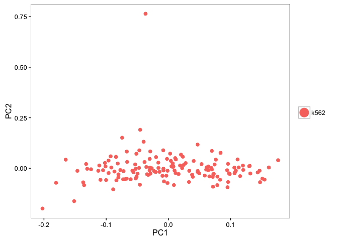

```r
> k562.seurat = pca(k562.seurat, pcs.print = 3, genes.print = 5, do.print = FALSE)
> pca.plot(k562.seurat, pt.size = 2)
```

### H1

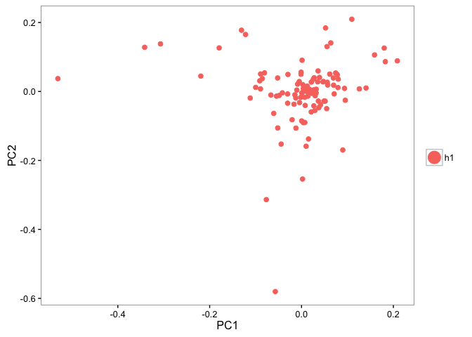

```r
> h1.seurat = pca(h1.seurat, pcs.print = 3, genes.print = 5, do.print = FALSE)
> pca.plot(h1.seurat, pt.size = 2)
```

### H2

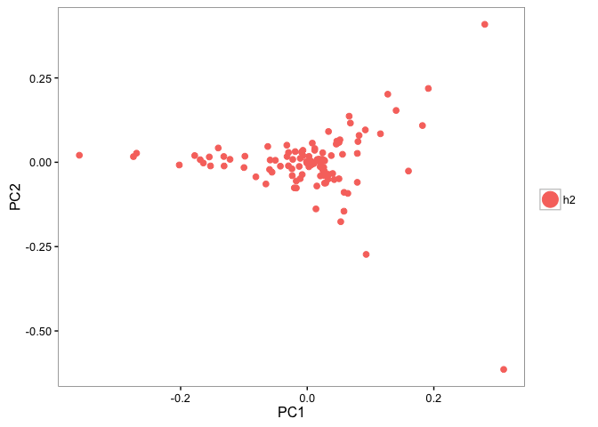

```r
> h2.seurat = pca(h2.seurat, pcs.print = 3, genes.print = 5, do.print = FALSE)
> pca.plot(h2.seurat, pt.size = 2)
```

### H3

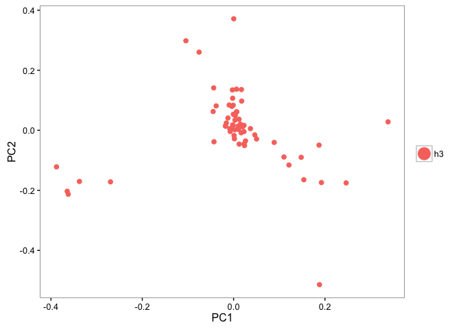

```r
> h3.seurat = pca(h3.seurat, pcs.print = 3, genes.print = 5, do.print = FALSE)
> pca.plot(h3.seurat, pt.size = 2)
```

```r
> top_200_heatmap = function(counts) {
+     counts = as.matrix(counts)
+     counts = head(counts[order(rowSums(counts), decreasing = TRUE), ], 200)
+     pheatmap(log(counts + 1), show_rownames = FALSE, show_colnames = FALSE)
+ }
```

### K562

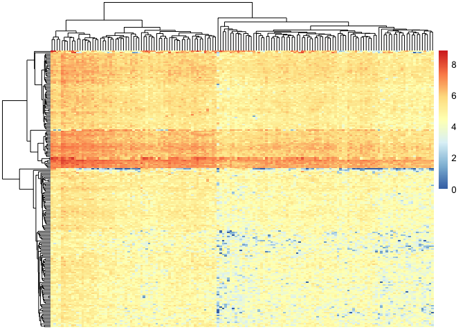

```r
> top_200_heatmap(k562)
```

### H1

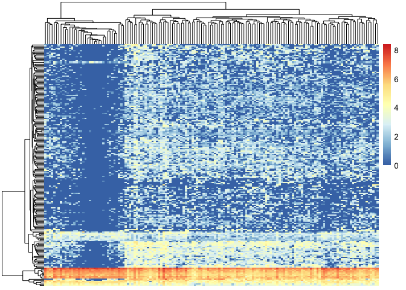

```r
> top_200_heatmap(h1)
```

### H2

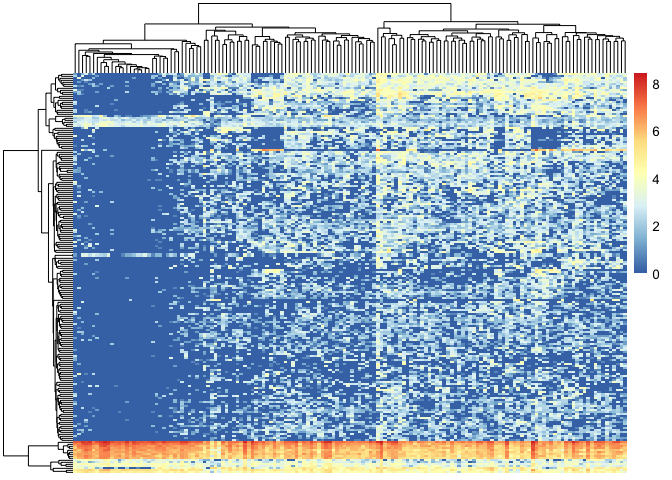

```r
> top_200_heatmap(h2)
```

### H3

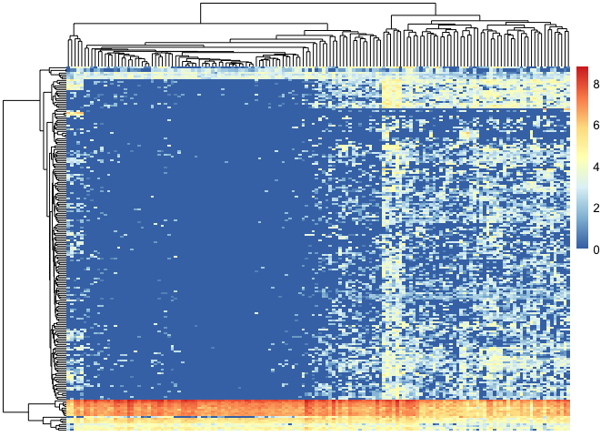

```r
> top_200_heatmap(h3)
```

## Housekeeping genes

I pulled a set of housekeeping genes from [Evidence Based Selection of Housekeeping Genes](http://journals.plos.org/plosone/article?id=10.1371/journal.pone.0000898) and converted them to human and mouse symbols. Then I made heatmaps for all of the housekeeping genes. We can see that for the K562 sample, most of the housekeeping genes are expressed strongly whereas in the H1-H3 samples, there is spare expression of the housekeeping genes.

```r
> hk = as.character(read.table("metadata/hk.txt", header = FALSE)[, "V1"])
> hk = c(hk, c("Actb", "Gapdh"))
> human_hk = as.character(read.table("metadata/human-hk.txt", header = FALSE)[,
+     "V1"])
> human_hk = c(human_hk, c("Actb", "Gapdh"))
> housekeeping_heatmap = function(counts, hk) {
+     counts = counts[rownames(counts) %in% hk, ]
+     pheatmap(log(counts + 1), show_rownames = TRUE, show_colnames = FALSE)
+ }
```

### K562

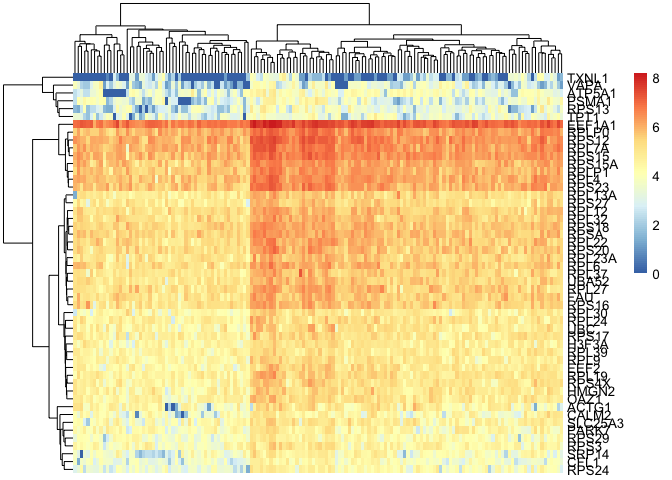

```r
> housekeeping_heatmap(k562, human_hk)
```

### K562 pseudo

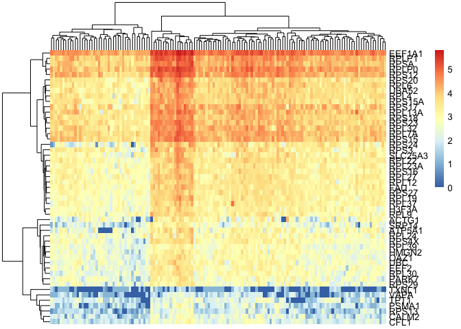

```r
> housekeeping_heatmap(k562_pseudo, human_hk)
```

### K562 quasi

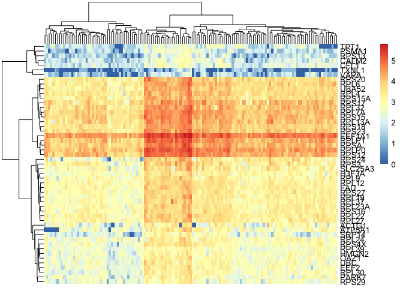

```r
> housekeeping_heatmap(k562_quasi, human_hk)
```

### H1

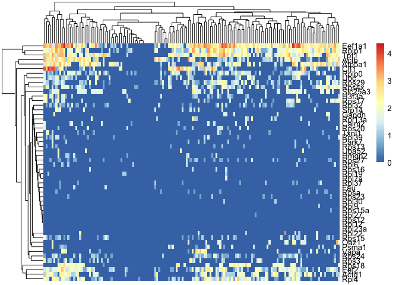

```r
> housekeeping_heatmap(h1, hk)
```

### H2

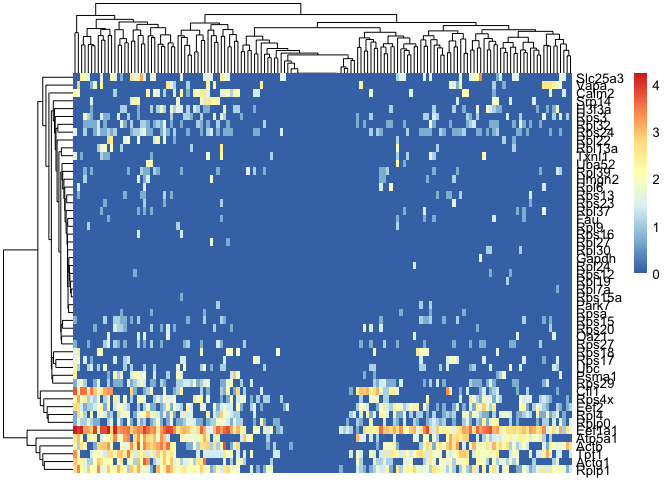

```r
> housekeeping_heatmap(h2, hk)
```

### H3

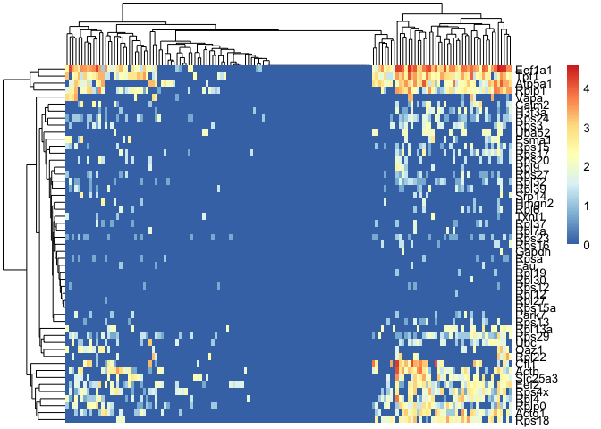

```r
> housekeeping_heatmap(h3, hk)
```

# Summary

It is hard to say what might be the cause of the problems we identified. If we could see the characteristic dip in the barcode distribution like we did for K562, I would feel pretty confident in recomending sequencing these samples some more. Since we do not see that dip, I’m not sure what to think.

I subsampled the K562 data and reran it, the distribution looks exactly the same and has the dip, so it isn’t due to the depth of sequencing. Next step is to look at the housekeeping genes.